# Predicting Red Wine Quality: Exploratory Data Analysis by Nagashri Nagaraj

# Table of Contents:

1. Introduction
2. Univariate Plots Section
3. Bivariate Plots Section
4. Multivariate Plots Section
5. Final Pltos & Summary
6. Reflection

## **Introduction**:

In this project we will explore which chemical property that will influence the quality of red wine. We will begin our data exploration and plotting with R program. Click [here](https://s3.amazonaws.com/udacity-hosted-downloads/ud651/wineQualityReds.csv.) to download the dataset and [here](https://s3.amazonaws.com/udacity-hosted-downloads/ud651/wineQualityInfo.txt) for more information on the Red Wine Quality data set.

## **Univariate Plots Section**:

### *Understand the Structure and Schema of the dataset*

```
## 'data.frame':    1599 obs. of  13 variables:
##  $ X                   : int  1 2 3 4 5 6 7 8 9 10 ...
##  $ fixed.acidity       : num  7.4 7.8 7.8 11.2 7.4 7.4 7.9 7.3 7.8 7.5 ...
##  $ volatile.acidity    : num  0.7 0.88 0.76 0.28 0.7 0.66 0.6 0.65 0.58 0.5 ...
##  $ citric.acid         : num  0 0 0.04 0.56 0 0 0.06 0 0.02 0.36 ...
##  $ residual.sugar      : num  1.9 2.6 2.3 1.9 1.9 1.8 1.6 1.2 2 6.1 ...
##  $ chlorides           : num  0.076 0.098 0.092 0.075 0.076 0.075 0.069 0.065 0.073 0.071 ...
##  $ free.sulfur.dioxide : num  11 25 15 17 11 13 15 15 9 17 ...
##  $ total.sulfur.dioxide: num  34 67 54 60 34 40 59 21 18 102 ...
##  $ density             : num  0.998 0.997 0.997 0.998 0.998 ...
##  $ pH                  : num  3.51 3.2 3.26 3.16 3.51 3.51 3.3 3.39 3.36 3.35 ...
##  $ sulphates           : num  0.56 0.68 0.65 0.58 0.56 0.56 0.46 0.47 0.57 0.8 ...
##  $ alcohol             : num  9.4 9.8 9.8 9.8 9.4 9.4 9.4 10 9.5 10.5 ...
##  $ quality             : int  5 5 5 6 5 5 5 7 7 5 ...
```

```
##        X          fixed.acidity   volatile.acidity  citric.acid
##  Min.   :   1.0   Min.   : 4.60   Min.   :0.1200   Min.   :0.000
##  1st Qu.: 400.5   1st Qu.: 7.10   1st Qu.:0.3900   1st Qu.:0.090
##  Median : 800.0   Median : 7.90   Median :0.5200   Median :0.260
##  Mean   : 800.0   Mean   : 8.32   Mean   :0.5278   Mean   :0.271
##  3rd Qu.:1199.5   3rd Qu.: 9.20   3rd Qu.:0.6400   3rd Qu.:0.420
##  Max.   :1599.0   Max.   :15.90   Max.   :1.5800   Max.   :1.000
##  residual.sugar     chlorides       free.sulfur.dioxide
##  Min.   : 0.900   Min.   :0.01200   Min.   : 1.00
##  1st Qu.: 1.900   1st Qu.:0.07000   1st Qu.: 7.00
##  Median : 2.200   Median :0.07900   Median :14.00
##  Mean   : 2.539   Mean   :0.08747   Mean   :15.87
##  3rd Qu.: 2.600   3rd Qu.:0.09000   3rd Qu.:21.00
##  Max.   :15.500   Max.   :0.61100   Max.   :72.00
##  total.sulfur.dioxide    density             pH          sulphates
##  Min.   :  6.00       Min.   :0.9901   Min.   :2.740   Min.   :0.3300
##  1st Qu.: 22.00       1st Qu.:0.9956   1st Qu.:3.210   1st Qu.:0.5500
##  Median : 38.00       Median :0.9968   Median :3.310   Median :0.6200
##  Mean   : 46.47       Mean   :0.9967   Mean   :3.311   Mean   :0.6581
##  3rd Qu.: 62.00       3rd Qu.:0.9978   3rd Qu.:3.400   3rd Qu.:0.7300
##  Max.   :289.00       Max.   :1.0037   Max.   :4.010   Max.   :2.0000
##     alcohol         quality
##  Min.   : 8.40   Min.   :3.000
##  1st Qu.: 9.50   1st Qu.:5.000
##  Median :10.20   Median :6.000
##  Mean   :10.42   Mean   :5.636
##  3rd Qu.:11.10   3rd Qu.:6.000
##  Max.   :14.90   Max.   :8.000
```

```
##
##   3   4   5   6   7   8
##  10  53 681 638 199  18
```

### *Initial Observations*:

- There are 1599 observations and 13 variables
- First variable X represents the user ID
- Quality of red wine `range` from 3 to 8. With `median` of 6 and `mean` of 5.6

## Univariant Plots

### *Histogram*:

To explore the data visually, we will draw up the histogram of all the 12 variables to see the distribution of values.

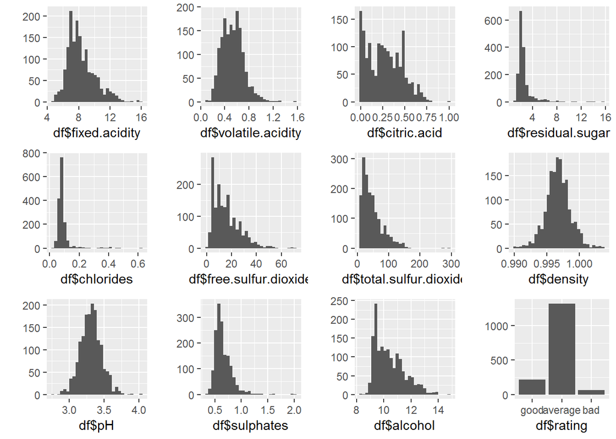

Total number of zero values in citric.acid variable

```
## [1] 132
```

**Histogram observations:**

- `density` and `pH` have **Normal Distribution**.
- `volatile.acidity`, `sulfurdioxides`, `sulphates` and alcohol have **Long Tailed Distribution**
- resedual sugar have **Extreme outliers**
- citric acid has large number of **zero values**(132). This could be due to unreported data

### *Bar Graph*:

To see the distribution of rating, we will plot bar graph.

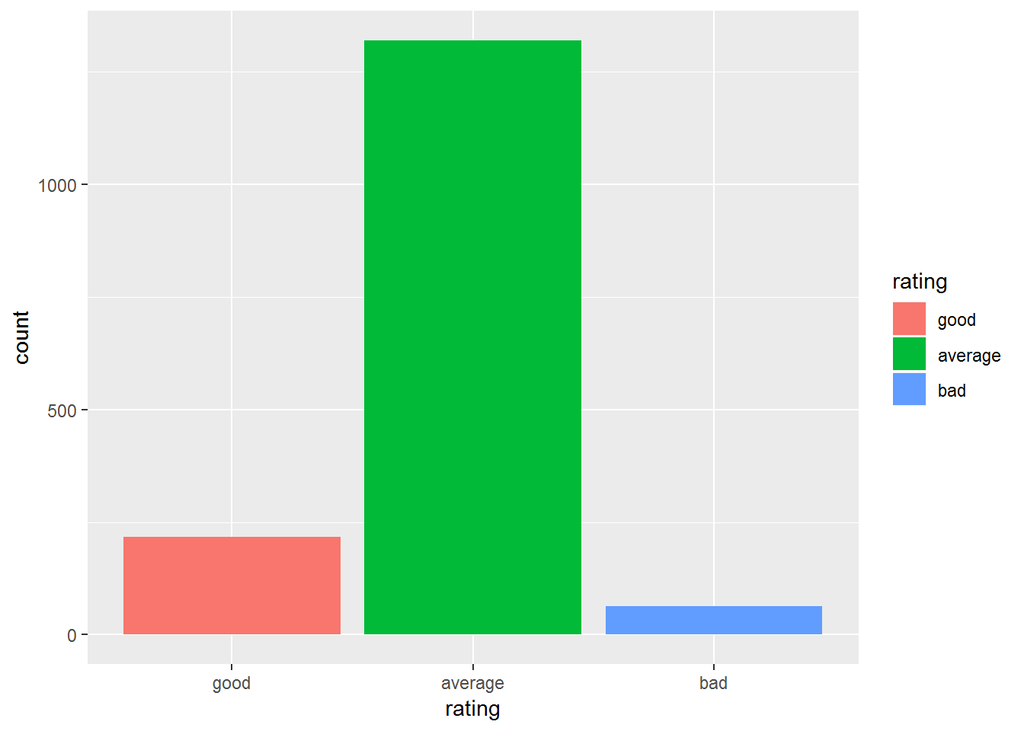

**Bar Graph observations:**

The graph shows there are more `average` rated wine and very few `bad` wine.

### *Logarithmic Scale Conversion*:

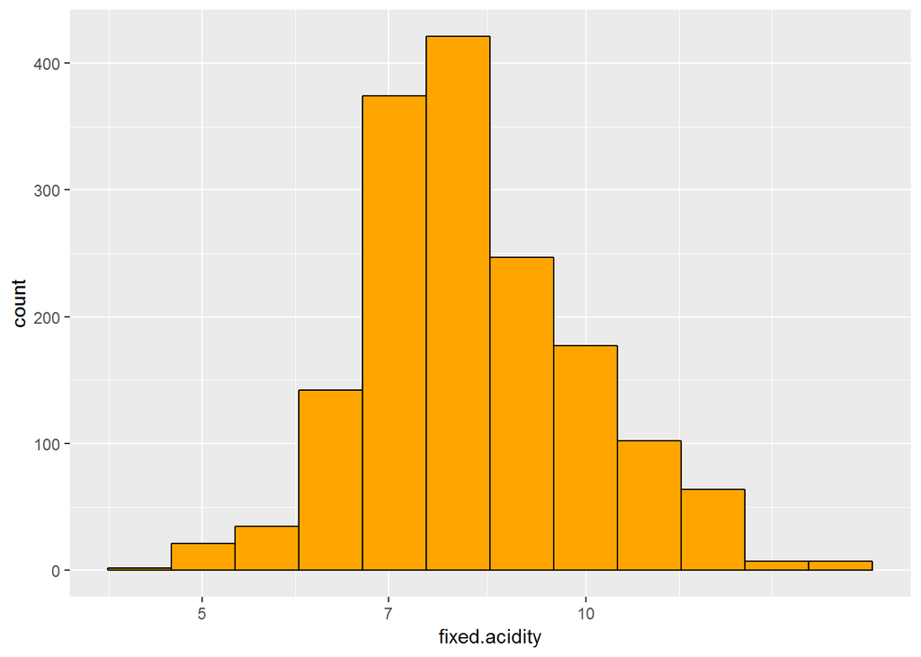

[figure not shown]

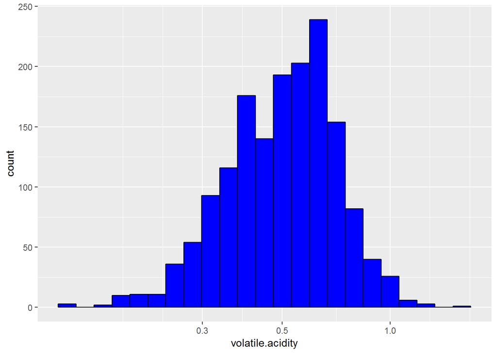

**Logarithmic Scale Conversion Analysis:**

The distribution looks more normal after conversion.

## **Bivariate Plots Section**

To analyse how different variables affect the quality of wine, we will generate box plots

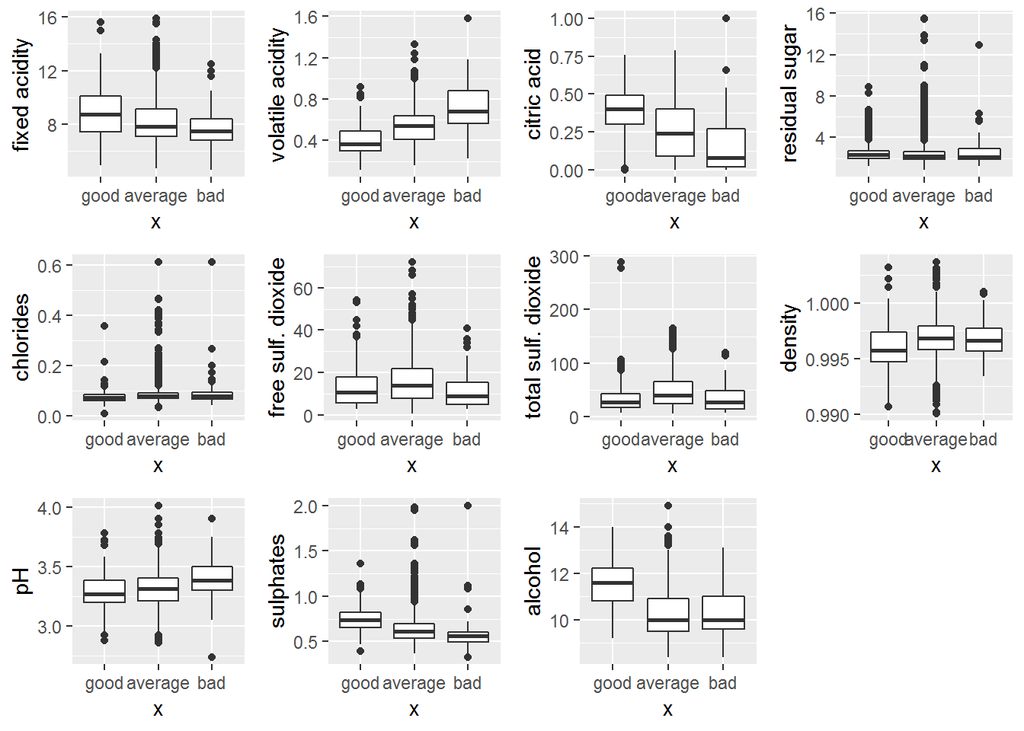

**Analysis Based on Box Plot**

Good wine has:

- Higher acid
- Lower pH
- Higher Sulphates
- Higher Alcohol
- To a lesser extend, lower chlorides & lower diensity

### *ggpairs*

- **Lower Triangle** of plot matrix gives grouped histogram for qualitative, qualitative pairs and scatter plots for quantitative, quantative pairs.
- **Upper Triangle** of plot gives histograms for quantitative, quantitative paris. This time it uses x instead of the y vaiable as the group factor. Box plots for quantitative, quantative pairs
- And it produces **Correlation** for quantitative, quantative pairs

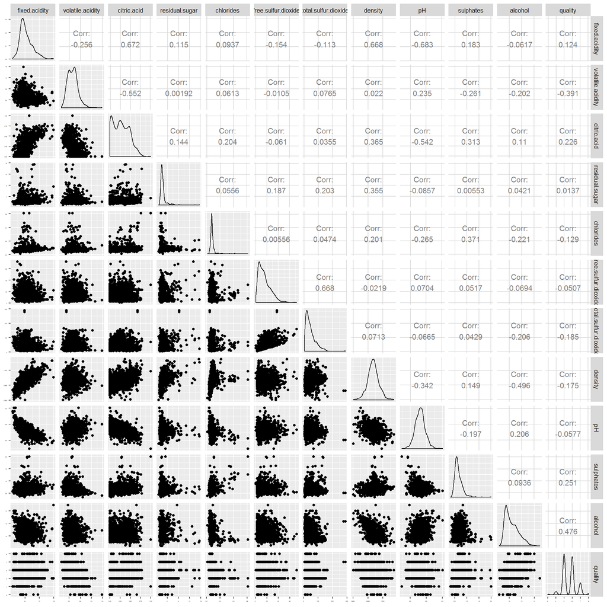

### Find correlation between quality of wine and the variables

```
##        fixed.acidity     volatile.acidity          citric.acid
##           0.12405165          -0.39055778           0.22637251
##       residual.sugar            chlordies  free.sulfur.dioxide
##           0.01373164          -0.12890656          -0.05065606
## total.sulfur.dioxide              density                   pH
##          -0.18510029          -0.17491923          -0.05773139
##            sulphates              alcohol
##           0.25139708           0.47616632
```

**ggpairs and correlation coefficient analysis:**

It appears, the following variables have higher correlation to quality of wine:

- Alcohol
- Sulphates
- Volatile acidity
- Citric Acid

It will be interesing to see the plots of the variables with strong correlation:

### **Plotting correlation between the variables**:

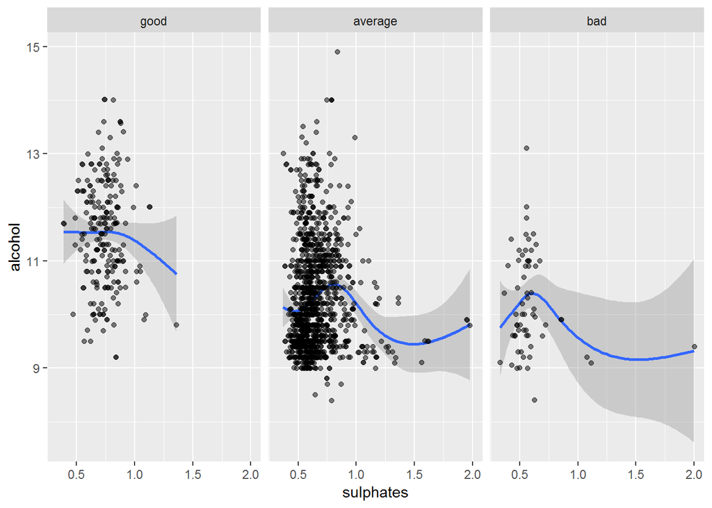

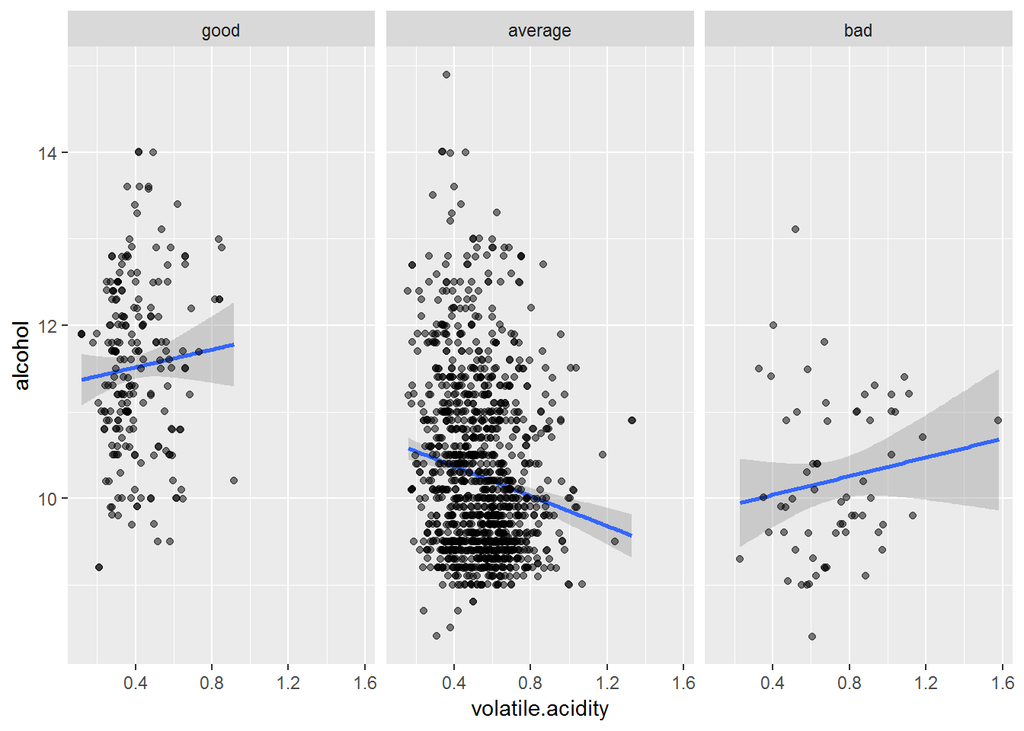

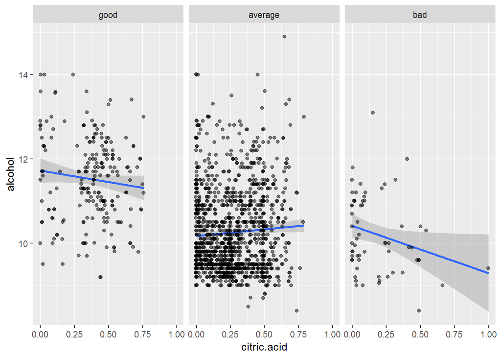

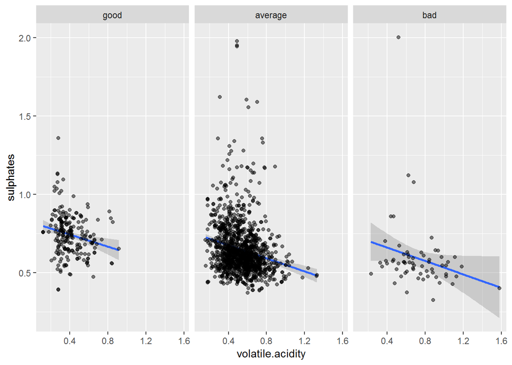

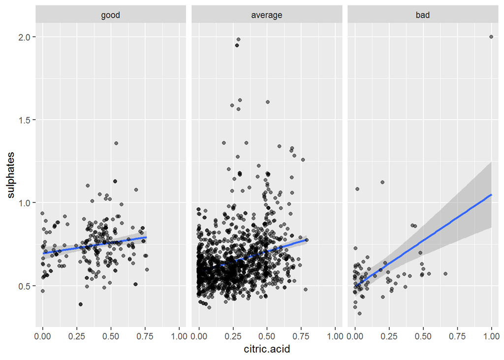

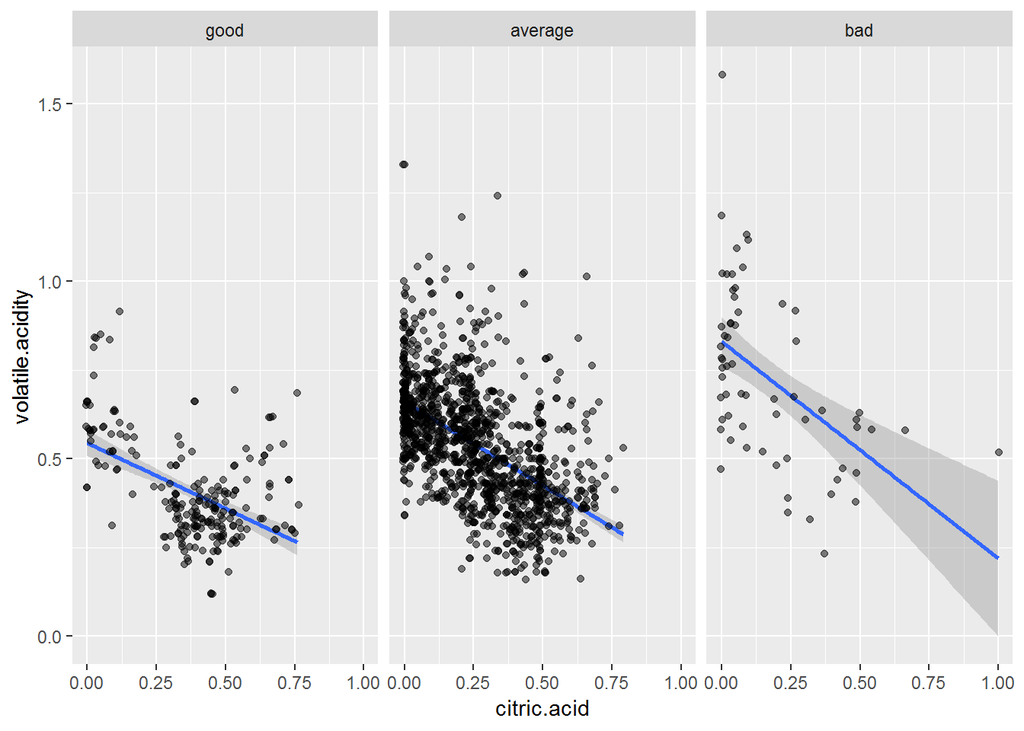

**Correlation between 2 variable, Analysis:**

It appears the combination of the above selected variables are dense in the average wine quality.

## **Multivariate Plots Section**

We will be examining the combination of variables that have positive correlation on the quality of wine in the plots.

- Higher citric acid, sulphates and alcohol contributes to better quality wine
- Lower volitile acid contributes better quality wine
- pH has very little effect on quality of wine

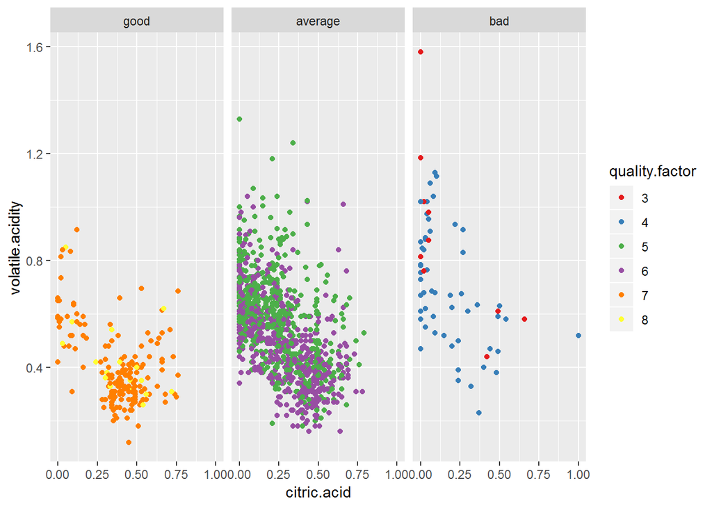

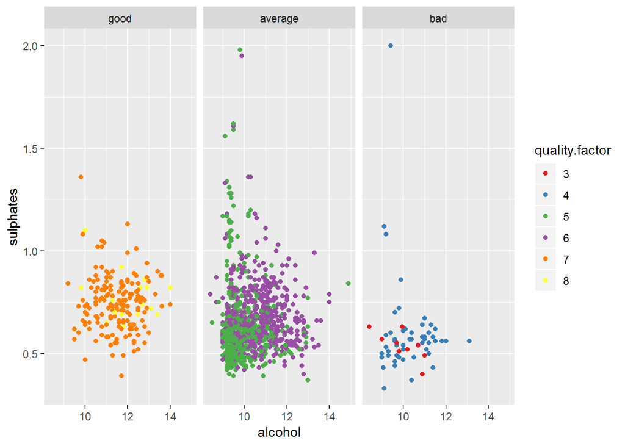

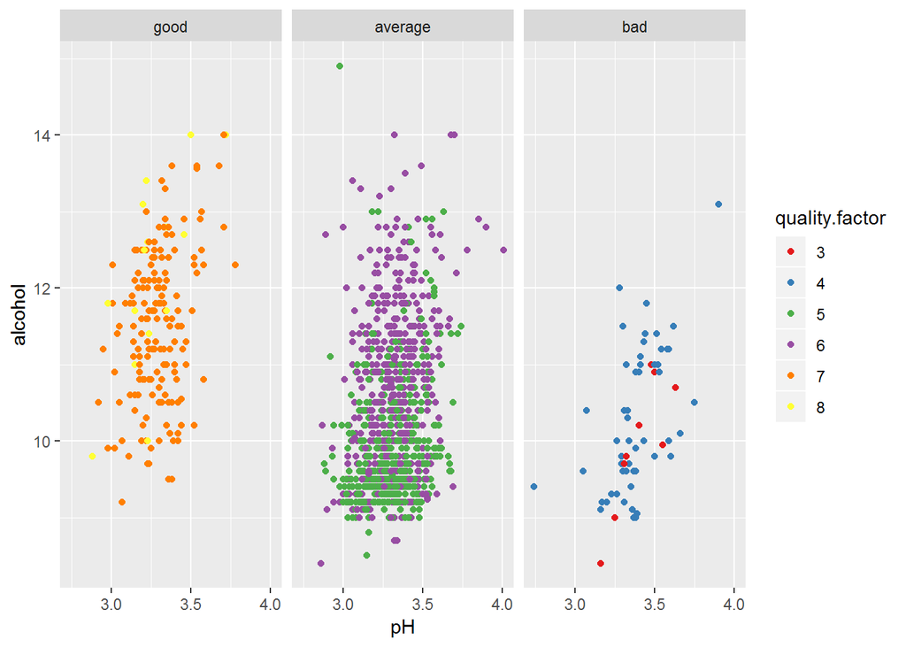

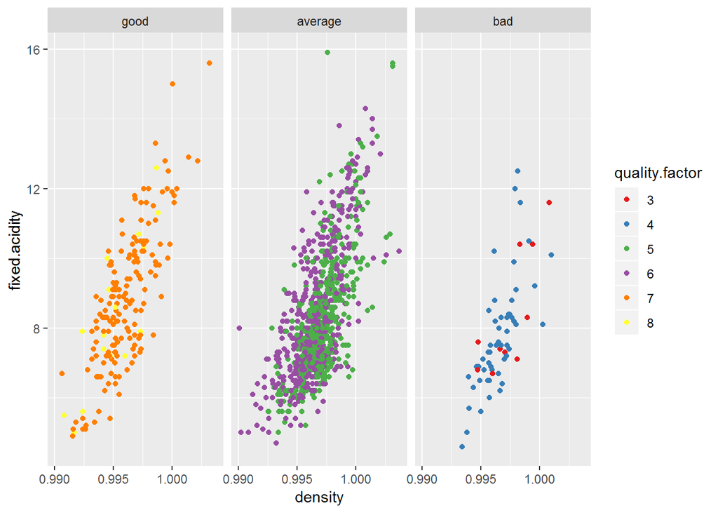

**Plot Analysis:**

By adding `quality.factor` representing color, we can see how quality and rating behaves with the variables. The plot between `alcohol` and `pH`, the average wine appears almost `exponential.Density` and `fixed.acidity` shows very strong linear correlation.

**Relation between alcohol and volatile acidity** looks interesting in good and bad wines. So subsetting the dataframe to remove average rating to see the relation between alcohol and volatile acidity in good and bad wines

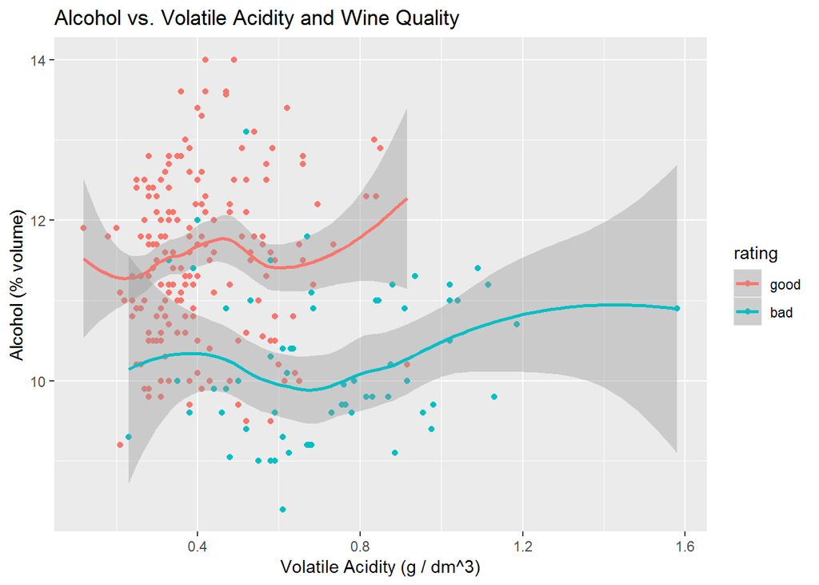

**Analysis**

- Good quality wine has more alcohol content and less volatile acidity
- Bad quality wine has less alcool content and more volatile acidity

### Multiple Regression Model

We are combining 2 or more variables for multiple regression model predicting the quality of wine.

```
##
## Calls:
## m1: lm(formula = quality ~ alcohol * sulphates * volatile.acidity,
##     data = df)
## m2: lm(formula = quality ~ alcohol + sulphates + volatile.acidity +
##     density + fixed.acidity + alcohol:sulphates + alcohol:volatile.acidity +
##     sulphates:volatile.acidity + density:fixed.acidity + alcohol:sulphates:volatile.acidity,
##     data = df)
## m3: lm(formula = quality ~ alcohol + sulphates + volatile.acidity +
##     density + fixed.acidity + alcohol:sulphates + alcohol:volatile.acidity +
##     sulphates:volatile.acidity + density:fixed.acidity + alcohol:sulphates:volatile.acidity,
##     data = df)
## m4: lm(formula = quality ~ alcohol + sulphates + volatile.acidity +
##     density + fixed.acidity + citric.acid + alcohol:sulphates +
##     alcohol:volatile.acidity + sulphates:volatile.acidity + density:fixed.acidity +
##     alcohol:sulphates:volatile.acidity, data = df)
##
## =============================================================================================
##                                               m1          m2           m3           m4
## ---------------------------------------------------------------------------------------------
##   (Intercept)                                 1.285     -24.559      -24.559      -32.364
##                                              (2.188)    (38.595)     (38.595)     (38.567)
##   alcohol                                     0.426*      0.372        0.372        0.419*
##                                              (0.209)     (0.212)      (0.212)      (0.212)
##   sulphates                                   2.713       2.525        2.525        3.016
##                                              (3.226)     (3.234)      (3.234)      (3.229)
##   volatile.acidity                            9.044*      8.388*       8.388*       8.673*
##                                              (4.030)     (4.029)      (4.029)      (4.019)
##   alcohol x sulphates                        -0.184      -0.177       -0.177       -0.219
##                                              (0.309)     (0.310)      (0.310)      (0.310)
##   alcohol x volatile.acidity                 -0.996*     -0.936*      -0.936*      -0.980*
##                                              (0.389)     (0.389)      (0.389)      (0.388)
##   sulphates x volatile.acidity              -15.622*    -15.564*     -15.564*     -15.901**
##                                              (6.130)     (6.144)      (6.144)      (6.128)
##   alcohol x sulphates x volatile.acidity      1.524*      1.541**      1.541**      1.573**
##                                              (0.593)     (0.594)      (0.594)      (0.592)
##   density                                                26.056       26.056       33.354
##                                                         (38.429)     (38.429)     (38.391)
##   fixed.acidity                                           7.290        7.290        7.871
##                                                          (4.071)      (4.071)      (4.063)
##   density x fixed.acidity                                -7.258       -7.258       -7.815
##                                                          (4.080)      (4.080)      (4.072)
##   citric.acid                                                                      -0.429**
##                                                                                    (0.136)
## ---------------------------------------------------------------------------------------------
##   R-squared                                   0.351       0.357        0.357        0.361
##   adj. R-squared                              0.349       0.353        0.353        0.357
##   sigma                                       0.652       0.649        0.649        0.648
##   F                                         123.160      88.255       88.255       81.584
##   p                                           0.000       0.000        0.000        0.000
##   Log-likelihood                          -1580.453   -1573.283    -1573.283    -1568.303
##   Deviance                                  675.909     669.874      669.874      665.715
##   AIC                                      3178.905    3170.565     3170.565     3162.605
##   BIC                                      3227.300    3235.091     3235.091     3232.508
##   N                                        1599        1599         1599         1599
## =============================================================================================
```

## **Final Plots and Summary**

### Plot One

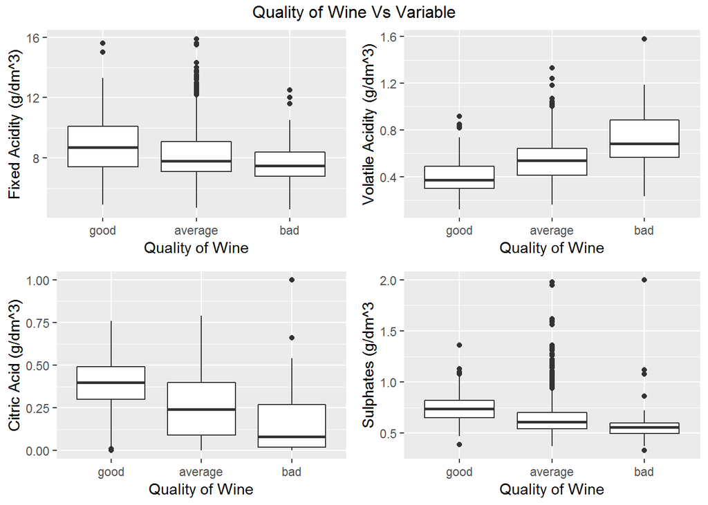

### Plot Two

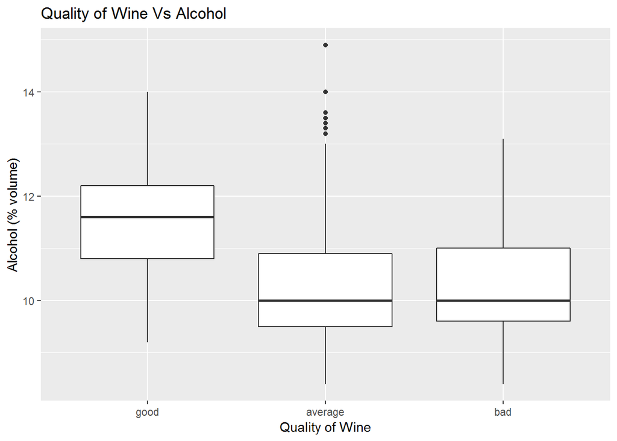

**Description Two:**

Alcohol has the strongest correlation with the quality of wine than any other variables. So we are plotting a Box plot of alcohol and quality of wine. Good quality wine has seems to have a sweet spot of alcohol content between 10.8 to 12.2 % volume.

### Plot Three

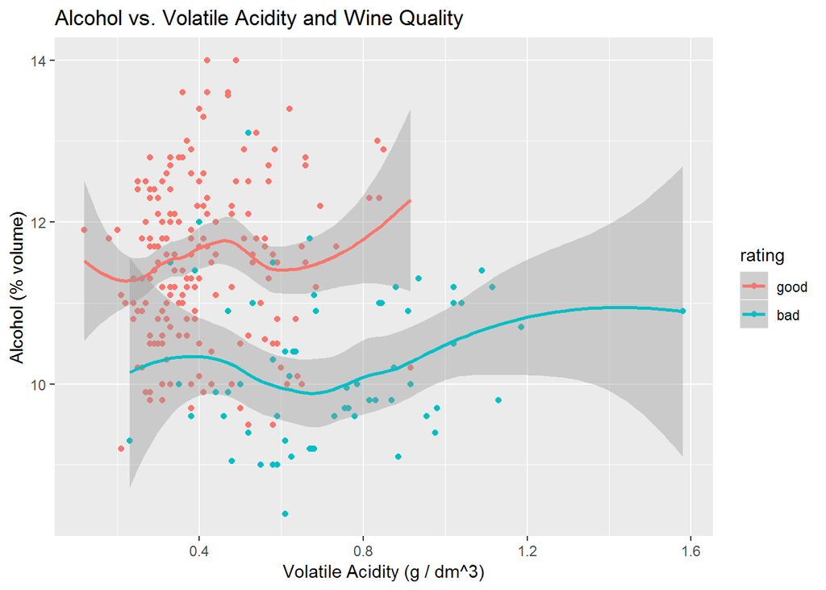

**Description Plot Three:**

- Relation between alcohol and volatile acidity looks interesting in good and bad wines. So subsetting the dataframe to remove average rating to see the relation between alcohol and volatile acidity in good and bad wines
- Good quality wine has more alcohol content and less volatile acidity
- Bad quality wine has less alcohol content and more volatile acidity

## **Reflection:**

**Challenges:**

- I first struggled in choosing the variables for the linear model.Later choose the variables with the highest R squared values
- I also had hard time understanding the linear model
- The most time consuming for me was learning html formats.

**Limitations:**

- We know the quality of red wine is not just determined by its chemical properties. Factors like smell and the quality/region of grape plays a very important role in the quality of wine. These factors are not accounted for in the given dataset.
- 1319 out of 1599 received 5 or 6 rating, 63 received 3 or 4 ratings, 217 received 7 or 8. No wine received 0, 1, 9, 10 ratings
- Since the quality variable has limited variability, it was difficult to assess relationship between quality and chemical attributes variable.

**Enriching analysis for future work:**

- For future analysis, I would like to see how white wine quality behaves with the same variables.